### Fig. 1.1 Global trend in case notifications of people newly diagnosed with TB, 2016–2020

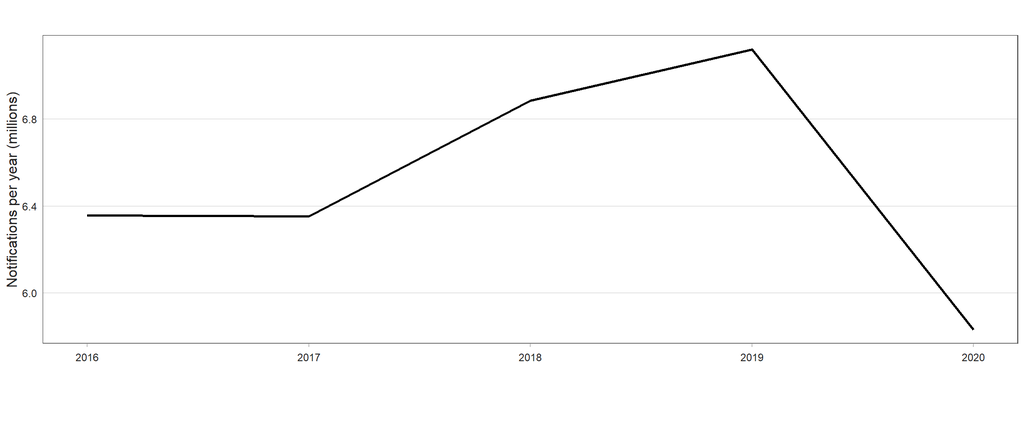

### Fig. 1.2 Trends in notifications of new and relapse TB cases by WHO region, 2016–2020

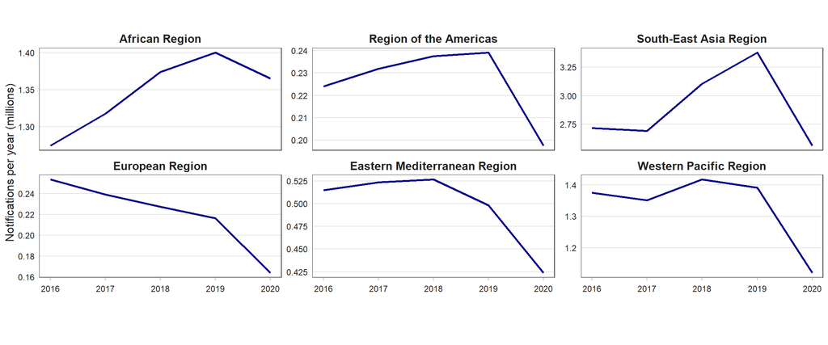

### Fig. 1.3 Trends in monthly or quarterly notifications of TB cases in selected high TB burden countries, January 2020–June 2021, <sup>a</sup>

The black line indicates the average number of monthly or quarterly case notifications in 2019.

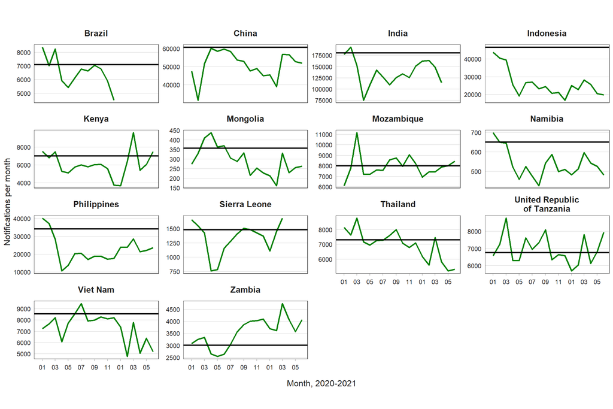

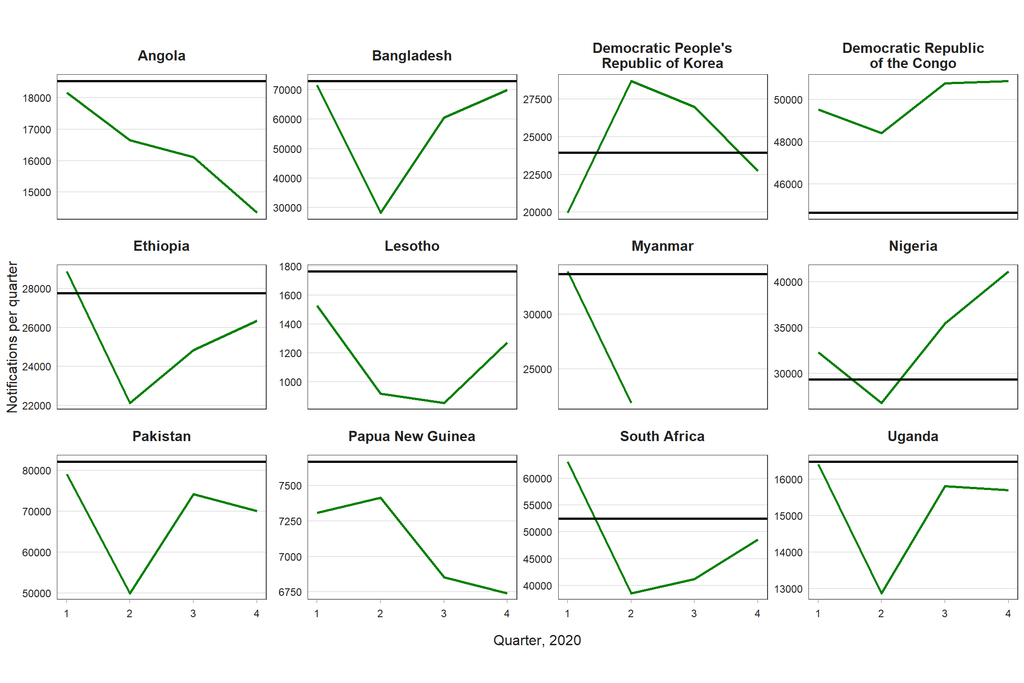

<sup>a</sup> Data are shown for countries that were able to report provisional national numbers for all months or quarters to WHO by July 2021.

### Fig. 1.4 Trends in monthly notifications of TB cases in India, January 2020–June 2021<sup>a</sup>

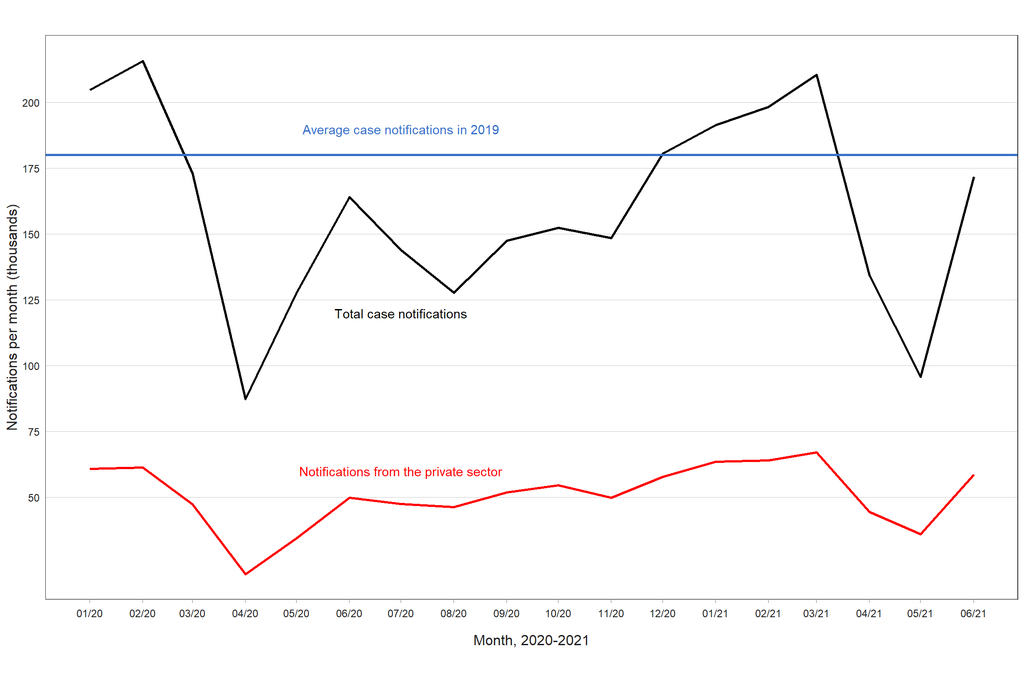

<sup>a</sup> These data were accessed from https://reports.nikshay.in/Reports/TBNotification on 20 July 2021.

### Fig. 1.5 TB notifications in 2020 compared with 2019 in the 30 high TB burden countries

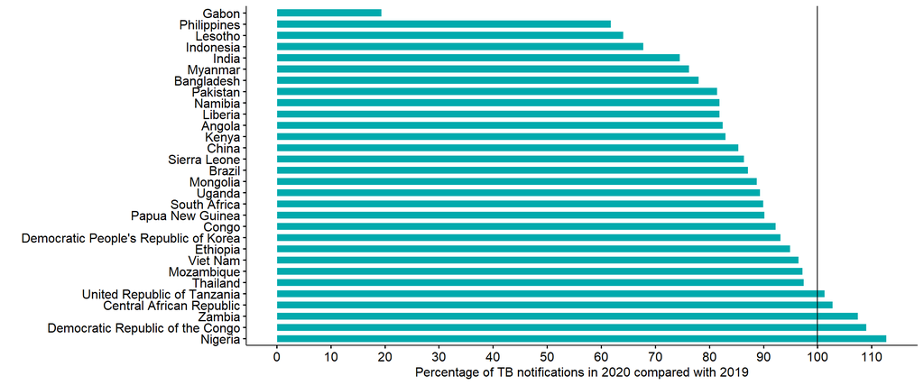

### Fig. 1.6 The 16 countries with the largest contributions to the global shortfall in TB notifications in 2020 compared with 2019

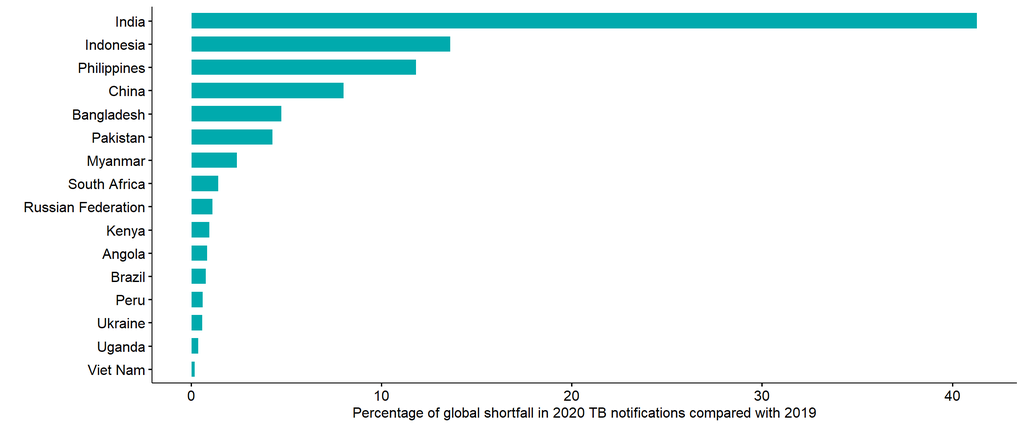

### Fig. 1.7 Estimated impact of the COVID-19 pandemic on TB mortality for 16 selected countries, up to 2025

Standardized TB mortality rate (including HIV)<sup>a</sup>

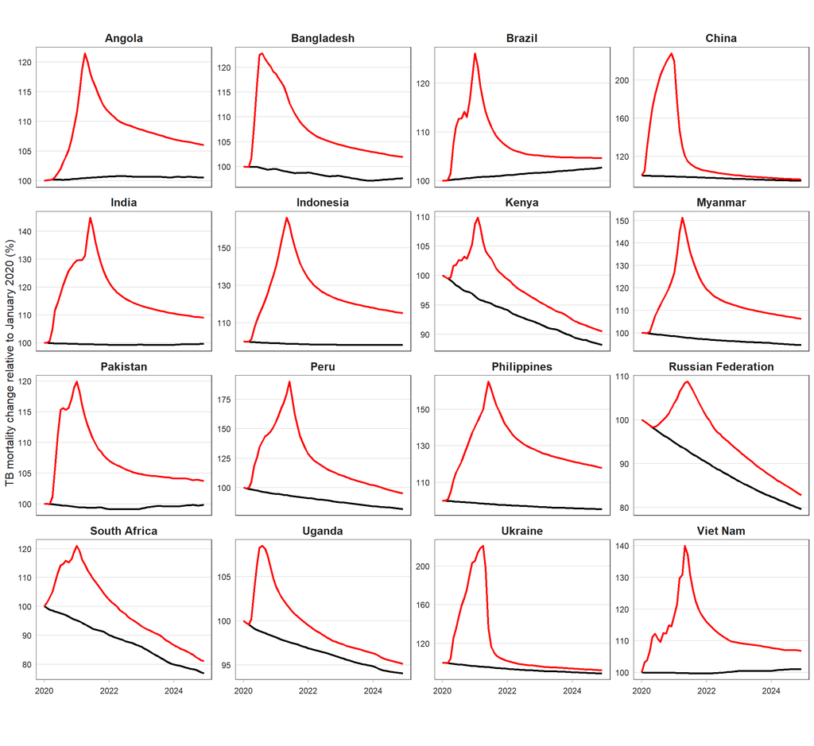

<sup>a</sup> These estimates are standardized so that rates in January 2020 equal 100 and all subsequent rates are relative to January 2020. For example, a reading of 115 translates into a 15% increase relative to January 2020. Baseline is a scenario of no COVID-19 disruptions based on pre-2020 trends. The impact of COVID-19 related disruptions on estimated mortality is noticeable from 2020 onward.

### Fig. 1.8 Estimated impact of the COVID-19 pandemic on TB incidence for 16 selected countries, up to 2025

Standardized TB incidence rate<sup>a</sup>

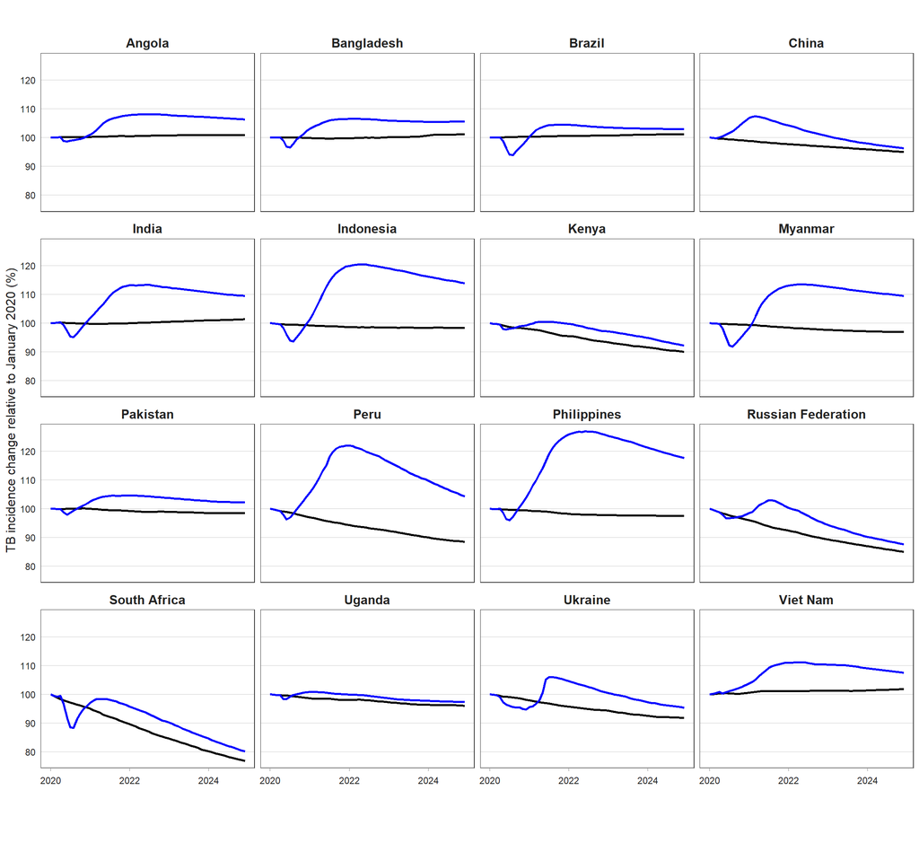

<sup>a</sup> These estimates are standardized so that rates in January 2020 equal 100 and all subsequent rates are relative to January 2020. For example, a reading of 115 translates into a 15% increase relative to January 2020. Baseline is a counterfactual scenario of no COVID-19, based on pre-2020 trends. The impact of COVID-19 related disruptions on estimated incidence is limited in 2020 and more noticeable in subsequent years.